# MLR in cryptocurrency pricing analysis: Proposal

```r
library(broom)
install.packages("latex2exp")
library(latex2exp)
library(tidyverse)
library(repr)
library(digest)
library(gridExtra)
install.packages("scatterplot3d")
library(scatterplot3d)

options(warn = -1)
```

```
Updating HTML index of packages in '.Library'

Making 'packages.html' ...
 done
```

[figure not shown]

## Introduction

### Background

Cryptocurrency is a decentralized "purely peer-to-peer version of electronic cash" (Nakamoto, 2009). ETH (Ether) is one of the native cryptocurrencies designed for the Ethereum platform (Buterin, n.d.). As the second cryptocurrency only to Bitcoin in market capitalization, ETH has a tenfold price increase in one year since November, 2020 ([Yahoo finance](https://finance.yahoo.com/quote/ETH-USD/)). The surging value of cryptocurrencies raises studies with computational tools for price prediction.

### Purpose

This study will apply MLR and assessment / selection methods on the ETH dataset, aiming to build an optimized model that explains the linearity between the same-day inputs and the price at the next day.

### Dataset

```r
eth <- read_csv('https://raw.githubusercontent.com/gzzen/stat-301-group-project/main/eth_dataset.csv')%>%na.omit()
head(eth, 2)
tail(eth, 2)
```

A tibble: 2 × 47

| date <date> | reddit_index <dbl> | block_size <dbl> | mining_difficulty <dbl> | ethe_open_interest <dbl> | activate_address <dbl> | on_chain_transaction_vol <dbl> | unit_computing_income <dbl> | daily_block_reward <dbl> | block_gen_rate <dbl> | ⋯ | trade_vol_l <dbl> | trade_vol_x <dbl> | short <dbl> | long <dbl> | ethe_otc_premium <dbl> | block_count <dbl> | avg_computing_power <dbl> | transaction_vol <dbl> | supply <dbl> | reddit_follower_growth_rate <dbl> |
| --- | --- | --- | --- | --- | --- | --- | --- | --- | --- | --- | --- | --- | --- | --- | --- | --- | --- | --- | --- | --- |
| 2020-06-24 | 2004.993 | 38301.08 | 2.405277e+15 | 1702398 | 566754 | 5530577 | 0.0202 | 3723607 | 13.4 | ⋯ | 0 | 0 | 141651691 | 137850993 | 3.5046 | 6450 | 1.916233e+14 | 1042273 | 108818350 | 0.086374 |
| 2020-06-25 | 2035.980 | 35299.83 | 2.406899e+15 | 1702281 | 584713 | 2795780 | 0.0197 | 3632507 | 13.4 | ⋯ | 0 | 0 | 128435656 | 115084909 | 3.0171 | 6448 | 1.915031e+14 | 1017408 | 108831273 | 0.101543 |

A tibble: 2 × 47

| date <date> | reddit_index <dbl> | block_size <dbl> | mining_difficulty <dbl> | ethe_open_interest <dbl> | activate_address <dbl> | on_chain_transaction_vol <dbl> | unit_computing_income <dbl> | daily_block_reward <dbl> | block_gen_rate <dbl> | ⋯ | trade_vol_l <dbl> | trade_vol_x <dbl> | short <dbl> | long <dbl> | ethe_otc_premium <dbl> | block_count <dbl> | avg_computing_power <dbl> | transaction_vol <dbl> | supply <dbl> | reddit_follower_growth_rate <dbl> |
| --- | --- | --- | --- | --- | --- | --- | --- | --- | --- | --- | --- | --- | --- | --- | --- | --- | --- | --- | --- | --- |
| 2021-10-28 | 254.6987 | 64129.10 | 1.006534e+16 | 3128001 | 826217 | 2972658 | 0.0858 | 63507365 | 13.6 | ⋯ | 180195352 | 152798432 | 4755173026 | 4677848018 | -0.0289822 | 6368 | 7.842797e+14 | 1456333 | 115181507 | 0.455180 |
| 2021-10-29 | 264.5458 | 62412.12 | 1.023876e+16 | 3128001 | 765907 | 1313643 | 0.0835 | 65172687 | 13.6 | ⋯ | 102822580 | 41716992 | 2839980504 | 2612652448 | -0.0289822 | 6345 | 7.986090e+14 | 1379095 | 115194221 | 0.391936 |

The raw data is pulled from [qkl123](https://www.qkl123.com/project/eth/data) that consists a comprehensive collection of featured indicators for ETH. The semi-finished dataset `eth_data` is then hand-crafted by merging columns with Python ([detailed process](https://github.com/gzzen/stat-301-group-project/blob/main/proposal/dataset/merge_dataset.ipynb)). Below we roughly peek at columns of the data.

```r
cat('Total number of columns: ', ncol(eth))
colnames(eth)
```

```
Total number of columns:  47
```

1. 'date'

2. 'reddit_index'

3. 'block_size'

4. 'mining_difficulty'

5. 'ethe_open_interest'

6. 'activate_address'

7. 'on_chain_transaction_vol'

8. 'unit_computing_income'

9. 'daily_block_reward'

10. 'block_gen_rate'

11. 'price'

12. 'open_interest_top100'

13. 'open_interest_top50'

14. 'open_interest_top30'

15. 'open_interest_top10'

16. 'avg_gas_cost'

17. 'unit_transaction_fee'

18. 'mining_vol'

19. 'margin_call_s'

20. 'margin_call_m'

21. 'margin_call_l'

22. 'margin_call_x'

23. 'short_margin_call'

24. 'long_margin_call'

25. 'new_addresses'

26. 'open_interest'

27. 'business_vol'

28. 'interest'

29. 'basis'

30. 'inflow_maker'

31. 'outflow_maker'

32. 'inflow_retail'

33. 'outflow_retail'

34. 'net'

35. 'daily_uncle_block_reward'

36. 'trade_vol_s'

37. 'trade_vol_m'

38. 'trade_vol_l'

39. 'trade_vol_x'

40. 'short'

41. 'long'

42. 'ethe_otc_premium'

43. 'block_count'

44. 'avg_computing_power'

45. 'transaction_vol'

46. 'supply'

47. 'reddit_follower_growth_rate'

The composition of dataset includes 47 columns spreading across 5 categories:

- `price` and `date` are the most basic figures in trading.
- `block_size`, `mining_difficulty`, etc. consists information of the blockchain.
- `business_vol`, `outflow_retail`, etc. are indicators in the spot market.
- `long_margin_call`, `margin_call_l`, etc. are indicators in the future market.
- `reddit_index`, `ethe_otc_premium`, etc. have no specific attributes, but are interesting to consider.

And we will further explain some of the variables after we reduce redundancy in the dataset.

## Preliminary Results

### Cleaning and wrangling

Now that we have our raw dataset ready, we can derive our target response: **next day's ETH price**, by moving our `price` column one unit upward. THis gives our new column `TARGET_price_nextday`.

```r
# switch the next-day price as the response variable of the same-day variables
price_temp = pull(eth, price)
TARGET_price_nextday <- price_temp[-1]
# we delete the first row of target because we don't have the explanatory variables from previous day
eth_data <- eth[-484,]
# we delete the last row because we don't have the actual target variable of the latest day, we'll have to wait till monday!
```

```r
# merge the operation with original dataset
eth_data <- cbind(eth_data, TARGET_price_nextday)
head(eth_data, 2)
tail(eth_data, 2)
```

A data.frame: 2 × 48

|  | date <date> | reddit_index <dbl> | block_size <dbl> | mining_difficulty <dbl> | ethe_open_interest <dbl> | activate_address <dbl> | on_chain_transaction_vol <dbl> | unit_computing_income <dbl> | daily_block_reward <dbl> | block_gen_rate <dbl> | ⋯ | trade_vol_x <dbl> | short <dbl> | long <dbl> | ethe_otc_premium <dbl> | block_count <dbl> | avg_computing_power <dbl> | transaction_vol <dbl> | supply <dbl> | reddit_follower_growth_rate <dbl> | TARGET_price_nextday <dbl> |
| --- | --- | --- | --- | --- | --- | --- | --- | --- | --- | --- | --- | --- | --- | --- | --- | --- | --- | --- | --- | --- | --- |
| 1 | 2020-06-24 | 2004.993 | 38301.08 | 2.405277e+15 | 1702398 | 566754 | 5530577 | 0.0202 | 3723607 | 13.4 | ⋯ | 0 | 141651691 | 137850993 | 3.5046 | 6450 | 1.916233e+14 | 1042273 | 108818350 | 0.086374 | 229.5401 |
| 2 | 2020-06-25 | 2035.980 | 35299.83 | 2.406899e+15 | 1702281 | 584713 | 2795780 | 0.0197 | 3632507 | 13.4 | ⋯ | 0 | 128435656 | 115084909 | 3.0171 | 6448 | 1.915031e+14 | 1017408 | 108831273 | 0.101543 | 227.2679 |

A data.frame: 2 × 48

|  | date <date> | reddit_index <dbl> | block_size <dbl> | mining_difficulty <dbl> | ethe_open_interest <dbl> | activate_address <dbl> | on_chain_transaction_vol <dbl> | unit_computing_income <dbl> | daily_block_reward <dbl> | block_gen_rate <dbl> | ⋯ | trade_vol_x <dbl> | short <dbl> | long <dbl> | ethe_otc_premium <dbl> | block_count <dbl> | avg_computing_power <dbl> | transaction_vol <dbl> | supply <dbl> | reddit_follower_growth_rate <dbl> | TARGET_price_nextday <dbl> |
| --- | --- | --- | --- | --- | --- | --- | --- | --- | --- | --- | --- | --- | --- | --- | --- | --- | --- | --- | --- | --- | --- |
| 482 | 2021-10-27 | 272.2137 | 67421.64 | 1.000351e+16 | 3128215 | 812670 | 1804725 | 0.0830 | 59779364 | 13.5 | ⋯ | 88796720 | 3930069648 | 3823507926 | -0.0205612 | 6408 | 7.821472e+14 | 1510502 | 115168748 | 0.37011 | 4452.810 |
| 483 | 2021-10-28 | 254.6987 | 64129.10 | 1.006534e+16 | 3128001 | 826217 | 2972658 | 0.0858 | 63507365 | 13.6 | ⋯ | 152798432 | 4755173026 | 4677848018 | -0.0289822 | 6368 | 7.842797e+14 | 1456333 | 115181507 | 0.45518 | 4290.951 |

We now have:

- `TARGET_price_nextday` as our **response variable**, and 46 variables as inputs to choose from (excluding date).

### Association between explanotory variables and response

To assure the viability of this model, we want to check that the collected data of the previous day are indeed associated with our targeted response, to do that, we first use`cor()` to test the correlation between our explanotory variables and response.

> Also notice: right now `TARGET_price_nextday` is also in the correlation chart, we need to get rid of that since it's the response we're looking for.

```r
# create correlation chart
eth_target_cor_chart <- data.frame(cor(eth_data[-1])) %>%
    select(TARGET_price_nextday)

# order the rows by correlation
colnames(eth_target_cor_chart) <- c('correlation')
correlation_data <-
    eth_target_cor_chart %>%
    arrange(desc(correlation)) %>%
    filter(correlation != 1)


head(correlation_data,3)
tail(correlation_data,3)
```

A data.frame: 3 × 1

|  | correlation <dbl> |
| --- | --- |
| price | 0.9956151 |
| daily_uncle_block_reward | 0.9836028 |
| avg_computing_power | 0.9708713 |

A data.frame: 3 × 1

|  | correlation <dbl> |
| --- | --- |
| reddit_index | -0.8151848 |
| outflow_retail | -0.8401814 |
| outflow_maker | -0.9406836 |

We are gladly surprised that the (absolute values of) correlations between a few explanotary variables and the response is very high. We can visualize all the correlations using a simple plot.

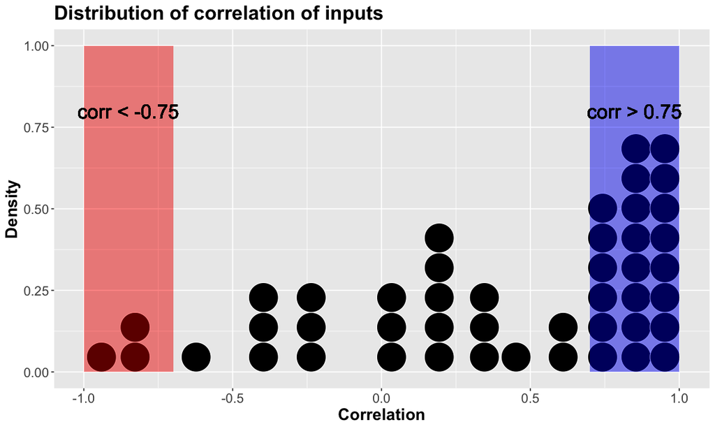

```r
# visualize correlation of inputs with the next-day price
eth_cor_histogram <-
    correlation_data %>%
    ggplot(aes(x=correlation)) +
    geom_dotplot(binwidth=1/10, color='white')  +
    geom_rect(aes(xmin=-1, xmax=-0.7, ymin=0, ymax=1), fill='red', alpha=0.01) +
    geom_rect(aes(xmin=0.7, xmax=1, ymin=0, ymax=1), fill='blue', alpha=0.01) +
    geom_text(x=-0.85, y=0.8, label='corr < -0.75', size=7) +
    geom_text(x=0.85, y=0.8, label='corr > 0.75', size=7) +
    labs(x='Correlation', y='Density', title='Distribution of correlation of inputs') +
    theme(
        text = element_text(size = 16.5),
        plot.title = element_text(face = "bold"),
        axis.title = element_text(face = "bold"))

eth_cor_histogram
```

Although there's no absolute standard, a correlation $corr>0.75$ or $corr<-0.75$ is usually considered strong. We can see here that quite a few variables meet those requirements in our plot, described by the red and blue region.

### SLR and MLR model

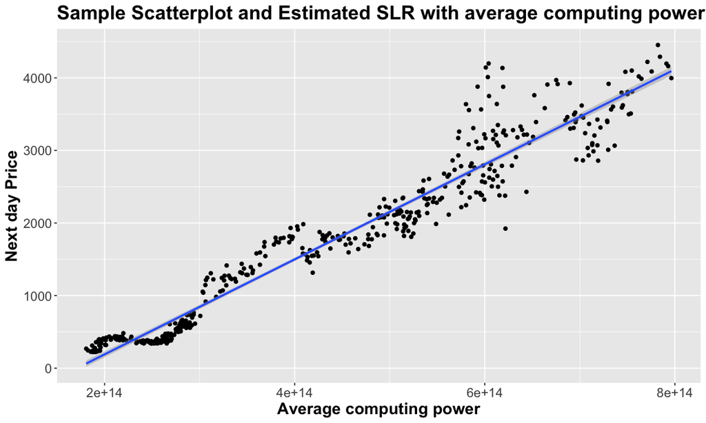

```r
options(repr.plot.width = 10, repr.plot.height = 6)

eth_sample_plot<- eth_data %>%
    ggplot(aes(x = avg_computing_power, y = TARGET_price_nextday))+
    geom_point()+
    geom_smooth(aes(x = avg_computing_power, y = TARGET_price_nextday),method = "lm")+
    xlab("Average computing power") +
    ylab("Next day Price") +
    ggtitle("Sample Scatterplot and Estimated SLR with average computing power") +
    theme(
        text = element_text(size = 16.5),
        plot.title = element_text(face = "bold"),
        axis.title = element_text(face = "bold")
    )

eth_sample_plot
```

Our plot seems promising already with only one variable. However, notice that as we're targeting at price here, we'd want our prediction to have a relatively small confidence interval so that it wouldn't contain previous day's price too often (in that case our prediction of ETH's gain/loss rate would be inconclusive). That's why we still need to put more variables into consider when conducting the model.

Below we include `reddit_index` and `on_chain_transaction_vol` to construct a two-variable MLR model, as to check how that fits in a 3-dimension coordinate.

```r
# MLR model
MLR_add_sample <- lm(TARGET_price_nextday~reddit_index+on_chain_transaction_vol, data=eth_data)

tidy(MLR_add_sample, conf.int=TRUE) %>% mutate_if(is.numeric, round, 2)
```

A tibble: 3 × 7

| term <chr> | estimate <dbl> | std.error <dbl> | statistic <dbl> | p.value <dbl> | conf.low <dbl> | conf.high <dbl> |
| --- | --- | --- | --- | --- | --- | --- |
| (Intercept) | 3655.05 | 87.51 | 41.77 | 0 | 3483.1 | 3827.00 |
| reddit_index | -1.98 | 0.06 | -32.59 | 0 | -2.1 | -1.86 |
| on_chain_transaction_vol | 0.00 | 0.00 | -7.67 | 0 | 0.0 | 0.00 |

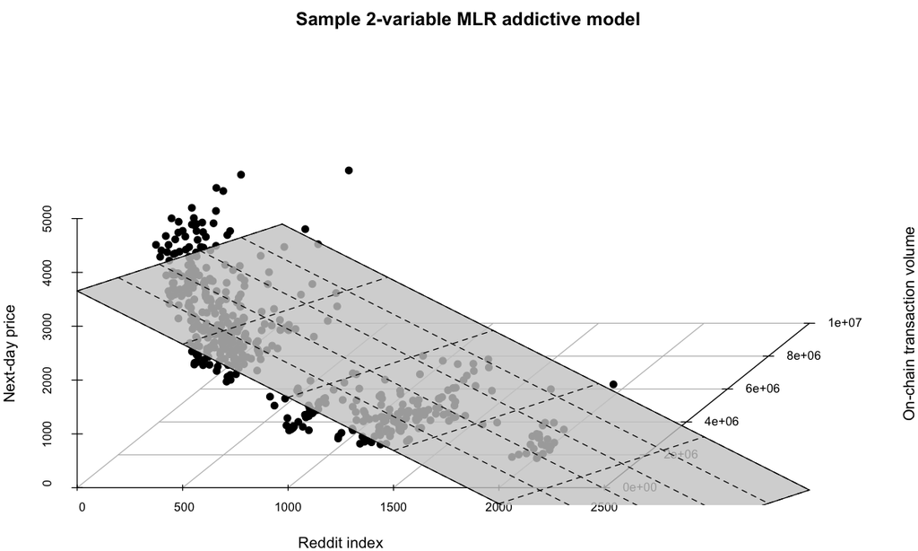

```r
# scatterplot
s3d <- scatterplot3d(x=eth_data$reddit_index, y=eth_data$on_chain_transaction_vol, z=TARGET_price_nextday, pch=19, type="p", color="black",
                     main="Sample 2-variable MLR addictive model", grid = TRUE, box = FALSE,
                     mar = c(2.5, 2.5, 2, 1.5), angle = 55, xlab='Reddit index', ylab='On-chain transaction volume', zlab='Next-day price')

s3d$plane3d(MLR_add_sample, draw_polygon = TRUE, draw_lines = TRUE, polygon_args = list(col = rgb(0.8,0.8,0.8,0.8)))
```

Note that most observations lies under the regression plane. The inequal distribution of scatters possibly implies that the association is non-linear, and the MLR model we just constructed may not be the best fit of our dataset.

## Method

#### What do you expect to achieve?

We expect to build a multiple linear regression model that is capable of accurately and percisely predicting the next-day's price of the cryptocurrency ETH.

#### What impact could your results have?

We want to see if such a model would be a relatively good prediction of ETH's trend in short term, and:

- If it turns out to be trust-worthy in the short term, would it hold up in the long-term?
- If we found that the model isn't a good prediction for ETH, would there be a better model to use in this case rather than multi-variable linear regression?
- If this model works well, would it be applicable to other crypto-currencies?

## Reference

Nakamoto, S. (2009). Bitcoin: A peer-to-peer electronic cash system. Retrieved from https://bitcoin.org/bitcoin.pdf.

Buterin, V. (n.d.). Ethereum whitepaper. Retrieved from https://ethereum.org/en/whitepaper/.